# Predição de prisões em ocorrências criminais em Chicago

**Projeto Final: Big Data e Computação em Nuvem**

*Por: Ilana Garcia, Izabelle Silva, Julia Navarro, Lívia Bertoni*

# Contexto do projeto

Este projeto trabalha com o conjunto de dados de **crimes registrados na cidade de Chicago** entre 2001 e 2023, disponibilizado pelo Chicago Police Department e organizado na plataforma Kaggle.  
Cada linha representa um **incidente criminal reportado**, contendo informações essenciais para análise temporal, espacial e contextual:

- variáveis temporais (data, hora, ano);
- tipo de crime e descrição detalhada;
- características do local (residência, comércio, escola, via pública etc.);
- indicadores importantes como **prisão realizada** **crime doméstico**;
- localização aproximada (quarteirão, distrito policial, área comunitária, latitude e longitude).

Para proteção da privacidade das vítimas, os endereços são aproximados: o nível máximo divulgado é o do quarteirão, e coordenadas são deslocadas.

**Ideia central:** construir um pipeline completo de Big Data utilizando Spark, desde a ingestão de milhões de registros até a preparação e execução de modelos preditivos, avaliando os fatores associados à realização de *prisões* em incidentes criminais.

# Visão geral do dataset

Abaixo, um resumo das principais variáveis que serão utilizadas na análise:

| Variável | Descrição | Tipo | Exemplo |
| --- | --- | --- | --- |
| `ID` | Identificador único do incidente | Inteiro | 12345678 |
| `Date` | Data e horário em que o crime foi registrado | Data/hora | 2019-07-15 23:45:00 |
| `Primary Type` | Categoria principal do crime | Categórica | THEFT, BATTERY, ROBBERY |
| `Description` | Descrição mais detalhada do tipo de crime | Categórica | OVER $500, SIMPLE, ARMED: HANDGUN |
| `Location Description` | Tipo de local onde ocorreu o crime | Categórica | STREET, RESIDENCE, SIDEWALK, SCHOOL |
| `Arrest` | Indica se houve prisão no incidente | Binária | TRUE / FALSE |
| `Domestic` | Indica se o crime está relacionado à violência doméstica | Binária | TRUE / FALSE |
| `Beat / District / Ward / Community Area` | Códigos administrativos de região policial e área comunitária | Inteiro / categórico | Beat 111, District 01, Community Area 32 |
| `Latitude / Longitude` | Coordenadas aproximadas do quarteirão do incidente | Numérico | 41.8781, -87.6298 |
| `Year` | Ano em que o crime foi registrado | Inteiro | 2008, 2015, 2023 |

# Objetivo da análise

A análise busca responder principalmente a duas questões:

# Configuração do Spark

Nesta seção configuramos e inicializamos uma sessão Spark — necessária para executar operações distribuídas de leitura, transformação e modelagem com DataFrames.

```python
from pyspark.sql import SparkSession
```

```python
spark = SparkSession.builder \
    .appName("Crimes Data Analysis") \
    .getOrCreate()
```

```python
spark
```

**SparkSession - in-memory**

**SparkContext**

[Spark UI](http://172.31.34.249:4045)

**Version**

`v3.5.6`

**Master**

`local[*]`

**AppName**

`Crimes Data Analysis`

# Importação do Dataset (KaggleHub)

Para iniciar o projeto, precisamos baixar a base de dados *Crimes In Chicago (2001 to 2023)* diretamente do Kaggle.  
Usamos a biblioteca **`kagglehub`**, que permite fazer o download automático da versão mais recente do dataset, garantindo praticidade e reprodutibilidade.

O código abaixo:

- importa o pacote `kagglehub`;
- baixa o dataset solicitado;
- salva o caminho local onde os arquivos foram armazenados;
- imprime esse caminho para ser usado nas próximas etapas do notebook.

Execute a célula de código logo abaixo:

```python
import kagglehub

# Download latest version
path = kagglehub.dataset_download("utkarshx27/crimes-2001-to-present")

print("Path to dataset files:", path)
```

```
Path to dataset files: /tmp/pads/.cache/kagglehub/datasets/utkarshx27/crimes-2001-to-present/versions/1
```

```python
from pyspark.sql.types import *

schema = StructType([
    StructField("ID", IntegerType(), True),
    StructField("Case Number", StringType(), True),
    StructField("Date", StringType(), True),
    StructField("Block", StringType(), True),
    StructField("IUCR", StringType(), True),
    StructField("Primary Type", StringType(), True),
    StructField("Description", StringType(), True),
    StructField("Location Description", StringType(), True),
    StructField("Arrest", BooleanType(), True),
    StructField("Domestic", BooleanType(), True),
    StructField("Beat", IntegerType(), True),
    StructField("District", IntegerType(), True),
    StructField("Ward", IntegerType(), True),
    StructField("Community Area", IntegerType(), True),
    StructField("FBI Code", StringType(), True),
    StructField("X Coordinate", FloatType(), True),
    StructField("Y Coordinate", FloatType(), True),
    StructField("Year", IntegerType(), True),
    StructField("Updated On", StringType(), True),
    StructField("Latitude", FloatType(), True),
    StructField("Longitude", FloatType(), True),
    StructField("Location", StringType(), True)
])
```

```python
crimes_df = spark.read.csv(path, header=True, schema=schema)
```

```python
crimes_df.show()
```

```
+--------+-----------+--------------------+--------------------+----+------------------+--------------------+--------------------+------+--------+----+--------+----+--------------+--------+------------+------------+----+--------------------+---------+----------+--------------------+
|      ID|Case Number|                Date|               Block|IUCR|      Primary Type|         Description|Location Description|Arrest|Domestic|Beat|District|Ward|Community Area|FBI Code|X Coordinate|Y Coordinate|Year|          Updated On| Latitude| Longitude|            Location|
+--------+-----------+--------------------+--------------------+----+------------------+--------------------+--------------------+------+--------+----+--------+----+--------------+--------+------------+------------+----+--------------------+---------+----------+--------------------+
|10224738|   HY411648|09/05/2015 01:30:...|     043XX S WOOD ST|0486|           BATTERY|DOMESTIC BATTERY ...|           RESIDENCE| false|    true| 924|       9|  12|            61|     08B|   1165074.0|   1875917.0|2015|02/10/2018 03:50:...|41.815117|    -87.67|(41.815117282, -8...|
|10224739|   HY411615|09/04/2015 11:30:...| 008XX N CENTRAL AVE|0870|             THEFT|      POCKET-PICKING|             CTA BUS| false|   false|1511|      15|  29|            25|      06|   1138875.0|   1904869.0|2015|02/10/2018 03:50:...| 41.89508|  -87.7654|(41.895080471, -8...|
|11646166|   JC213529|09/01/2018 12:01:...|082XX S INGLESIDE...|0810|             THEFT|           OVER $500|           RESIDENCE| false|    true| 631|       6|   8|            44|      06|        NULL|        NULL|2018|04/06/2019 04:04:...|     NULL|      NULL|                NULL|
|10224740|   HY411595|09/05/2015 12:45:...|   035XX W BARRY AVE|2023|         NARCOTICS|POSS: HEROIN(BRN/...|            SIDEWALK|  true|   false|1412|      14|  35|            21|      18|   1152037.0|   1920384.0|2015|02/10/2018 03:50:...|41.937405| -87.71665|(41.937405765, -8...|
|10224741|   HY411610|09/05/2015 01:00:...| 0000X N LARAMIE AVE|0560|           ASSAULT|              SIMPLE|           APARTMENT| false|    true|1522|      15|  28|            25|     08A|   1141706.0|   1900086.0|2015|02/10/2018 03:50:...|41.881905| -87.75512|(41.881903443, -8...|
|10224742|   HY411435|09/05/2015 10:55:...| 082XX S LOOMIS BLVD|0610|          BURGLARY|      FORCIBLE ENTRY|           RESIDENCE| false|   false| 614|       6|  21|            71|      05|   1168430.0|   1850165.0|2015|02/10/2018 03:50:...|41.744377| -87.65843|(41.744378879, -8...|
|10224743|   HY411629|09/04/2015 06:00:...|021XX W CHURCHILL ST|0620|          BURGLARY|      UNLAWFUL ENTRY|    RESIDENCE-GARAGE| false|   false|1434|      14|  32|            24|      05|   1161628.0|   1912157.0|2015|02/10/2018 03:50:...|41.914635| -87.68163|(41.914635603, -8...|
|10224744|   HY411605|09/05/2015 01:00:...|   025XX W CERMAK RD|0860|             THEFT|        RETAIL THEFT|  GROCERY FOOD STORE|  true|   false|1034|      10|  25|            31|      06|   1159734.0|   1889313.0|2015|09/17/2015 11:37:...| 41.85199| -87.68922|(41.851988885, -8...|
|10224745|   HY411654|09/05/2015 11:30:...|031XX W WASHINGTO...|0320|           ROBBERY|STRONGARM - NO WE...|              STREET| false|    true|1222|      12|  27|            27|      03|   1155536.0|   1900515.0|2015|02/10/2018 03:50:...|41.882812| -87.70432|(41.88281374, -87...|
|11645836|   JC212333|05/01/2016 12:25:...| 055XX S ROCKWELL ST|1153|DECEPTIVE PRACTICE|FINANCIAL IDENTIT...|                NULL| false|   false| 824|       8|  15|            63|      11|        NULL|        NULL|2016|04/06/2019 04:04:...|     NULL|      NULL|                NULL|
|10224746|   HY411662|09/05/2015 02:00:...|  071XX S PULASKI RD|0820|             THEFT|      $500 AND UNDER|PARKING LOT/GARAG...| false|   false| 833|       8|  13|            65|      06|   1150938.0|   1857056.0|2015|02/10/2018 03:50:...| 41.76365| -87.72234|(41.763647552, -8...|
|10224749|   HY411626|09/05/2015 11:00:...|052XX N MILWAUKEE...|0460|           BATTERY|              SIMPLE|  SMALL RETAIL STORE| false|   false|1623|      16|  45|            11|     08B|   1137969.0|   1934340.0|2015|02/10/2018 03:50:...|41.975967| -87.76801|(41.975968415, -8...|
|10224750|   HY411632|09/05/2015 03:00:...|    0000X W 103RD ST|2820|     OTHER OFFENSE|    TELEPHONE THREAT|           APARTMENT| false|    true| 512|       5|  34|            49|      26|   1177871.0|   1836676.0|2015|02/10/2018 03:50:...|41.707153|-87.624245|(41.707154919, -8...|
```

[output cut: 9 more lines]

```python
import pyspark.sql.functions as sf

crimes_df = (
    crimes_df.withColumn('Date', sf.to_timestamp('Date', 'MM/dd/yyyy hh:mm:ss a'))
      .withColumn('Updated On', sf.to_timestamp('Updated On', 'MM/dd/yyyy hh:mm:ss a'))
)
```

```python
crimes_df.printSchema()
```

```
root
 |-- ID: integer (nullable = true)
 |-- Case Number: string (nullable = true)
 |-- Date: timestamp (nullable = true)
 |-- Block: string (nullable = true)
 |-- IUCR: string (nullable = true)
 |-- Primary Type: string (nullable = true)
 |-- Description: string (nullable = true)
 |-- Location Description: string (nullable = true)
 |-- Arrest: boolean (nullable = true)
 |-- Domestic: boolean (nullable = true)
 |-- Beat: integer (nullable = true)
 |-- District: integer (nullable = true)
 |-- Ward: integer (nullable = true)
 |-- Community Area: integer (nullable = true)
 |-- FBI Code: string (nullable = true)
 |-- X Coordinate: float (nullable = true)
 |-- Y Coordinate: float (nullable = true)
 |-- Year: integer (nullable = true)
 |-- Updated On: timestamp (nullable = true)
 |-- Latitude: float (nullable = true)
 |-- Longitude: float (nullable = true)
 |-- Location: string (nullable = true)
```

```python
crimes_df.show()
```

```
+--------+-----------+-------------------+--------------------+----+------------------+--------------------+--------------------+------+--------+----+--------+----+--------------+--------+------------+------------+----+-------------------+---------+----------+--------------------+
|      ID|Case Number|               Date|               Block|IUCR|      Primary Type|         Description|Location Description|Arrest|Domestic|Beat|District|Ward|Community Area|FBI Code|X Coordinate|Y Coordinate|Year|         Updated On| Latitude| Longitude|            Location|
+--------+-----------+-------------------+--------------------+----+------------------+--------------------+--------------------+------+--------+----+--------+----+--------------+--------+------------+------------+----+-------------------+---------+----------+--------------------+
|10224738|   HY411648|2015-09-05 13:30:00|     043XX S WOOD ST|0486|           BATTERY|DOMESTIC BATTERY ...|           RESIDENCE| false|    true| 924|       9|  12|            61|     08B|   1165074.0|   1875917.0|2015|2018-02-10 15:50:01|41.815117|    -87.67|(41.815117282, -8...|
|10224739|   HY411615|2015-09-04 11:30:00| 008XX N CENTRAL AVE|0870|             THEFT|      POCKET-PICKING|             CTA BUS| false|   false|1511|      15|  29|            25|      06|   1138875.0|   1904869.0|2015|2018-02-10 15:50:01| 41.89508|  -87.7654|(41.895080471, -8...|
|11646166|   JC213529|2018-09-01 00:01:00|082XX S INGLESIDE...|0810|             THEFT|           OVER $500|           RESIDENCE| false|    true| 631|       6|   8|            44|      06|        NULL|        NULL|2018|2019-04-06 16:04:43|     NULL|      NULL|                NULL|
|10224740|   HY411595|2015-09-05 12:45:00|   035XX W BARRY AVE|2023|         NARCOTICS|POSS: HEROIN(BRN/...|            SIDEWALK|  true|   false|1412|      14|  35|            21|      18|   1152037.0|   1920384.0|2015|2018-02-10 15:50:01|41.937405| -87.71665|(41.937405765, -8...|
|10224741|   HY411610|2015-09-05 13:00:00| 0000X N LARAMIE AVE|0560|           ASSAULT|              SIMPLE|           APARTMENT| false|    true|1522|      15|  28|            25|     08A|   1141706.0|   1900086.0|2015|2018-02-10 15:50:01|41.881905| -87.75512|(41.881903443, -8...|
|10224742|   HY411435|2015-09-05 10:55:00| 082XX S LOOMIS BLVD|0610|          BURGLARY|      FORCIBLE ENTRY|           RESIDENCE| false|   false| 614|       6|  21|            71|      05|   1168430.0|   1850165.0|2015|2018-02-10 15:50:01|41.744377| -87.65843|(41.744378879, -8...|
|10224743|   HY411629|2015-09-04 18:00:00|021XX W CHURCHILL ST|0620|          BURGLARY|      UNLAWFUL ENTRY|    RESIDENCE-GARAGE| false|   false|1434|      14|  32|            24|      05|   1161628.0|   1912157.0|2015|2018-02-10 15:50:01|41.914635| -87.68163|(41.914635603, -8...|
|10224744|   HY411605|2015-09-05 13:00:00|   025XX W CERMAK RD|0860|             THEFT|        RETAIL THEFT|  GROCERY FOOD STORE|  true|   false|1034|      10|  25|            31|      06|   1159734.0|   1889313.0|2015|2015-09-17 11:37:18| 41.85199| -87.68922|(41.851988885, -8...|
|10224745|   HY411654|2015-09-05 11:30:00|031XX W WASHINGTO...|0320|           ROBBERY|STRONGARM - NO WE...|              STREET| false|    true|1222|      12|  27|            27|      03|   1155536.0|   1900515.0|2015|2018-02-10 15:50:01|41.882812| -87.70432|(41.88281374, -87...|
|11645836|   JC212333|2016-05-01 00:25:00| 055XX S ROCKWELL ST|1153|DECEPTIVE PRACTICE|FINANCIAL IDENTIT...|                NULL| false|   false| 824|       8|  15|            63|      11|        NULL|        NULL|2016|2019-04-06 16:04:43|     NULL|      NULL|                NULL|
|10224746|   HY411662|2015-09-05 14:00:00|  071XX S PULASKI RD|0820|             THEFT|      $500 AND UNDER|PARKING LOT/GARAG...| false|   false| 833|       8|  13|            65|      06|   1150938.0|   1857056.0|2015|2018-02-10 15:50:01| 41.76365| -87.72234|(41.763647552, -8...|
|10224749|   HY411626|2015-09-05 11:00:00|052XX N MILWAUKEE...|0460|           BATTERY|              SIMPLE|  SMALL RETAIL STORE| false|   false|1623|      16|  45|            11|     08B|   1137969.0|   1934340.0|2015|2018-02-10 15:50:01|41.975967| -87.76801|(41.975968415, -8...|
|10224750|   HY411632|2015-09-05 03:00:00|    0000X W 103RD ST|2820|     OTHER OFFENSE|    TELEPHONE THREAT|           APARTMENT| false|    true| 512|       5|  34|            49|      26|   1177871.0|   1836676.0|2015|2018-02-10 15:50:01|41.707153|-87.624245|(41.707154919, -8...|
```

[output cut: 9 more lines]

```python
from pyspark.sql import functions as F

crimes_df = crimes_df.select(
    F.col("ID").alias("id"),
    F.col("Case Number").alias("case_number"),
    F.col("Date").alias("date"),
    F.col("Block").alias("block"),
    F.col("IUCR").alias("iucr"),
    F.col("Primary Type").alias("primary_type"),
    F.col("Description").alias("description"),
    F.col("Location Description").alias("location_description"),
    F.col("Arrest").alias("arrest"),
    F.col("Domestic").alias("domestic"),
    F.col("Beat").alias("beat"),
    F.col("District").alias("district"),
    F.col("Ward").alias("ward"),
    F.col("Community Area").alias("community_area"),
    F.col("FBI Code").alias("fbi_code"),
    F.col("X Coordinate").alias("x_coordinate"),
    F.col("Y Coordinate").alias("y_coordinate"),
    F.col("Year").alias("year"),
    F.col("Updated On").alias("updated_on"),
    F.col("Latitude").alias("latitude"),
    F.col("Longitude").alias("longitude"),
    F.col("Location").alias("location"))
```

```python
crimes_df.limit(10).toPandas()
```

|  | id | case_number | date | block | iucr | primary_type | description | location_description | arrest | domestic | ... | ward | community_area | fbi_code | x_coordinate | y_coordinate | year | updated_on | latitude | longitude | location |
| --- | --- | --- | --- | --- | --- | --- | --- | --- | --- | --- | --- | --- | --- | --- | --- | --- | --- | --- | --- | --- | --- |
| 0 | 10224738 | HY411648 | 2015-09-05 13:30:00 | 043XX S WOOD ST | 0486 | BATTERY | DOMESTIC BATTERY SIMPLE | RESIDENCE | False | True | ... | 12 | 61 | 08B | 1165074.0 | 1875917.0 | 2015 | 2018-02-10 15:50:01 | 41.815117 | -87.669998 | (41.815117282, -87.669999562) |
| 1 | 10224739 | HY411615 | 2015-09-04 11:30:00 | 008XX N CENTRAL AVE | 0870 | THEFT | POCKET-PICKING | CTA BUS | False | False | ... | 29 | 25 | 06 | 1138875.0 | 1904869.0 | 2015 | 2018-02-10 15:50:01 | 41.895081 | -87.765404 | (41.895080471, -87.765400451) |
| 2 | 11646166 | JC213529 | 2018-09-01 00:01:00 | 082XX S INGLESIDE AVE | 0810 | THEFT | OVER $500 | RESIDENCE | False | True | ... | 8 | 44 | 06 | NaN | NaN | 2018 | 2019-04-06 16:04:43 | NaN | NaN | None |
| 3 | 10224740 | HY411595 | 2015-09-05 12:45:00 | 035XX W BARRY AVE | 2023 | NARCOTICS | POSS: HEROIN(BRN/TAN) | SIDEWALK | True | False | ... | 35 | 21 | 18 | 1152037.0 | 1920384.0 | 2015 | 2018-02-10 15:50:01 | 41.937405 | -87.716652 | (41.937405765, -87.716649687) |
| 4 | 10224741 | HY411610 | 2015-09-05 13:00:00 | 0000X N LARAMIE AVE | 0560 | ASSAULT | SIMPLE | APARTMENT | False | True | ... | 28 | 25 | 08A | 1141706.0 | 1900086.0 | 2015 | 2018-02-10 15:50:01 | 41.881905 | -87.755119 | (41.881903443, -87.755121152) |
| 5 | 10224742 | HY411435 | 2015-09-05 10:55:00 | 082XX S LOOMIS BLVD | 0610 | BURGLARY | FORCIBLE ENTRY | RESIDENCE | False | False | ... | 21 | 71 | 05 | 1168430.0 | 1850165.0 | 2015 | 2018-02-10 15:50:01 | 41.744377 | -87.658432 | (41.744378879, -87.658430635) |
| 6 | 10224743 | HY411629 | 2015-09-04 18:00:00 | 021XX W CHURCHILL ST | 0620 | BURGLARY | UNLAWFUL ENTRY | RESIDENCE-GARAGE | False | False | ... | 32 | 24 | 05 | 1161628.0 | 1912157.0 | 2015 | 2018-02-10 15:50:01 | 41.914635 | -87.681633 | (41.914635603, -87.681630909) |
| 7 | 10224744 | HY411605 | 2015-09-05 13:00:00 | 025XX W CERMAK RD | 0860 | THEFT | RETAIL THEFT | GROCERY FOOD STORE | True | False | ... | 25 | 31 | 06 | 1159734.0 | 1889313.0 | 2015 | 2015-09-17 11:37:18 | 41.851990 | -87.689217 | (41.851988885, -87.689219118) |
| 8 | 10224745 | HY411654 | 2015-09-05 11:30:00 | 031XX W WASHINGTON BLVD | 0320 | ROBBERY | STRONGARM - NO WEAPON | STREET | False | True | ... | 27 | 27 | 03 | 1155536.0 | 1900515.0 | 2015 | 2018-02-10 15:50:01 | 41.882812 | -87.704323 | (41.88281374, -87.704325717) |
| 9 | 11645836 | JC212333 | 2016-05-01 00:25:00 | 055XX S ROCKWELL ST | 1153 | DECEPTIVE PRACTICE | FINANCIAL IDENTITY THEFT OVER $ 300 | None | False | False | ... | 15 | 63 | 11 | NaN | NaN | 2016 | 2019-04-06 16:04:43 | NaN | NaN | None |

10 rows × 22 columns

```python
num_rows = crimes_df.count()
num_cols = len(crimes_df.columns)

print(num_rows, num_cols)
```

```
[Stage 1010:=>                                                    (1 + 31) / 32]
```

```
7784664 22
```

```python
crimes_df_s = crimes_df.sample(fraction=0.1, seed=42)
```

```python
crimes_df.describe()
```

```
DataFrame[summary: string, id: string, case_number: string, block: string, iucr: string, primary_type: string, description: string, location_description: string, beat: string, district: string, ward: string, community_area: string, fbi_code: string, x_coordinate: string, y_coordinate: string, year: …
```

Analisando Valores Nulos

```python
print("Linhas:", crimes_df.count())
print("Colunas:", len(crimes_df.columns))
```

```
Linhas: 7784664
Colunas: 22
```

```python
crimes_df.show(5, truncate=False)
```

```
+--------+-----------+-------------------+---------------------+----+------------+-----------------------+--------------------+------+--------+----+--------+----+--------------+--------+------------+------------+----+-------------------+---------+---------+-----------------------------+
|id      |case_number|date               |block                |iucr|primary_type|description            |location_description|arrest|domestic|beat|district|ward|community_area|fbi_code|x_coordinate|y_coordinate|year|updated_on         |latitude |longitude|location                     |
+--------+-----------+-------------------+---------------------+----+------------+-----------------------+--------------------+------+--------+----+--------+----+--------------+--------+------------+------------+----+-------------------+---------+---------+-----------------------------+
|10224738|HY411648   |2015-09-05 13:30:00|043XX S WOOD ST      |0486|BATTERY     |DOMESTIC BATTERY SIMPLE|RESIDENCE           |false |true    |924 |9       |12  |61            |08B     |1165074.0   |1875917.0   |2015|2018-02-10 15:50:01|41.815117|-87.67   |(41.815117282, -87.669999562)|
|10224739|HY411615   |2015-09-04 11:30:00|008XX N CENTRAL AVE  |0870|THEFT       |POCKET-PICKING         |CTA BUS             |false |false   |1511|15      |29  |25            |06      |1138875.0   |1904869.0   |2015|2018-02-10 15:50:01|41.89508 |-87.7654 |(41.895080471, -87.765400451)|
|11646166|JC213529   |2018-09-01 00:01:00|082XX S INGLESIDE AVE|0810|THEFT       |OVER $500              |RESIDENCE           |false |true    |631 |6       |8   |44            |06      |NULL        |NULL        |2018|2019-04-06 16:04:43|NULL     |NULL     |NULL                         |
|10224740|HY411595   |2015-09-05 12:45:00|035XX W BARRY AVE    |2023|NARCOTICS   |POSS: HEROIN(BRN/TAN)  |SIDEWALK            |true  |false   |1412|14      |35  |21            |18      |1152037.0   |1920384.0   |2015|2018-02-10 15:50:01|41.937405|-87.71665|(41.937405765, -87.716649687)|
|10224741|HY411610   |2015-09-05 13:00:00|0000X N LARAMIE AVE  |0560|ASSAULT     |SIMPLE                 |APARTMENT           |false |true    |1522|15      |28  |25            |08A     |1141706.0   |1900086.0   |2015|2018-02-10 15:50:01|41.881905|-87.75512|(41.881903443, -87.755121152)|
+--------+-----------+-------------------+---------------------+----+------------+-----------------------+--------------------+------+--------+----+--------+----+--------------+--------+------------+------------+----+-------------------+---------+---------+-----------------------------+
only showing top 5 rows
```

```python
from pyspark.sql.functions import col, sum

total = crimes_df.count()

nulos = crimes_df.select([
    (sum(col(c).isNull().cast("int")) / total*100).alias(c)
    for c in crimes_df.columns
])

nulos_pd = nulos.toPandas()

nulos_pd
```

|  | id | case_number | date | block | iucr | primary_type | description | location_description | arrest | domestic | ... | ward | community_area | fbi_code | x_coordinate | y_coordinate | year | updated_on | latitude | longitude | location |
| --- | --- | --- | --- | --- | --- | --- | --- | --- | --- | --- | --- | --- | --- | --- | --- | --- | --- | --- | --- | --- | --- |
| 0 | 0.0 | 0.000051 | 0.0 | 0.0 | 0.0 | 0.0 | 0.0 | 0.133352 | 0.0 | 0.0 | ... | 7.898196 | 7.880571 | 0.0 | 1.115629 | 1.115629 | 0.0 | 0.0 | 1.115629 | 1.115629 | 1.115629 |

1 rows × 22 columns

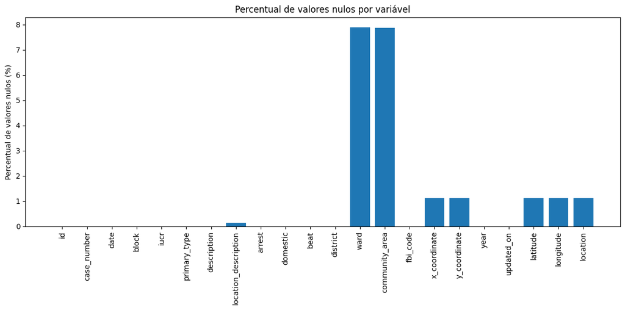

```python
import matplotlib.pyplot as plt

# Converter Spark -> Pandas
nulos_pd = nulos.toPandas().T.reset_index()
nulos_pd.columns = ["variavel", "percent_nulls"]

plt.figure(figsize=(12, 6))
plt.bar(nulos_pd["variavel"], nulos_pd["percent_nulls"])
plt.xticks(rotation=90)
plt.ylabel("Percentual de valores nulos (%)")
plt.title("Percentual de valores nulos por variável")
plt.tight_layout()
plt.show()
```

```python
crimes_df2 = crimes_df.na.drop()
```

```python
print("Linhas pré tratamento:", crimes_df.count())
print("Linhas pós tratamento de nulos", crimes_df2.count())
```

```
Linhas pré tratamento: 7784664
```

```
[Stage 21:=============================>                         (17 + 15) / 32]
```

```
Linhas pós tratamento de nulos 7084435
```

```python
from pyspark.sql.functions import approx_count_distinct as acd

card_df2 = crimes_df2.select([
    acd(c).alias(f"{c}_approx_unique")
    for c in crimes_df2.columns
])

card_pd = card_df2.toPandas().T
card_pd.columns = ["approx_unique"]
card_pd
```

```
25/12/06 21:20:04 WARN SparkStringUtils: Truncated the string representation of a plan since it was too large. This behavior can be adjusted by setting 'spark.sql.debug.maxToStringFields'.
```

|  | approx_unique |
| --- | --- |
| id_approx_unique | 7010933 |
| case_number_approx_unique | 6892944 |
| date_approx_unique | 2965609 |
| block_approx_unique | 35056 |
| iucr_approx_unique | 386 |
| primary_type_approx_unique | 36 |
| description_approx_unique | 516 |
| location_description_approx_unique | 226 |
| arrest_approx_unique | 2 |
| domestic_approx_unique | 2 |
| beat_approx_unique | 328 |
| district_approx_unique | 25 |
| ward_approx_unique | 49 |
| community_area_approx_unique | 79 |
| fbi_code_approx_unique | 27 |
| x_coordinate_approx_unique | 73738 |
| y_coordinate_approx_unique | 119819 |
| year_approx_unique | 24 |
| updated_on_approx_unique | 4664 |
| latitude_approx_unique | 84442 |
| longitude_approx_unique | 39758 |
| location_approx_unique | 677206 |

```python
crimes_df2.groupBy("primary_type") \
         .count() \
         .orderBy("count", ascending=False) \
         .show(20, truncate=False)
```

```
[Stage 27:=============================================>          (26 + 6) / 32]
```

```
+--------------------------------+-------+
|primary_type                    |count  |
+--------------------------------+-------+
|THEFT                           |1499197|
|BATTERY                         |1299859|
|CRIMINAL DAMAGE                 |811905 |
|NARCOTICS                       |669097 |
|ASSAULT                         |465810 |
|OTHER OFFENSE                   |440288 |
|BURGLARY                        |390418 |
|MOTOR VEHICLE THEFT             |339630 |
|DECEPTIVE PRACTICE              |302833 |
|ROBBERY                         |267994 |
|CRIMINAL TRESPASS               |195986 |
|WEAPONS VIOLATION               |100385 |
|PROSTITUTION                    |61348  |
|OFFENSE INVOLVING CHILDREN      |49456  |
|PUBLIC PEACE VIOLATION          |48705  |
|SEX OFFENSE                     |26311  |
|CRIM SEXUAL ASSAULT             |24123  |
|INTERFERENCE WITH PUBLIC OFFICER|17821  |
|GAMBLING                        |13405  |
|LIQUOR LAW VIOLATION            |12782  |
+--------------------------------+-------+
only showing top 20 rows
```

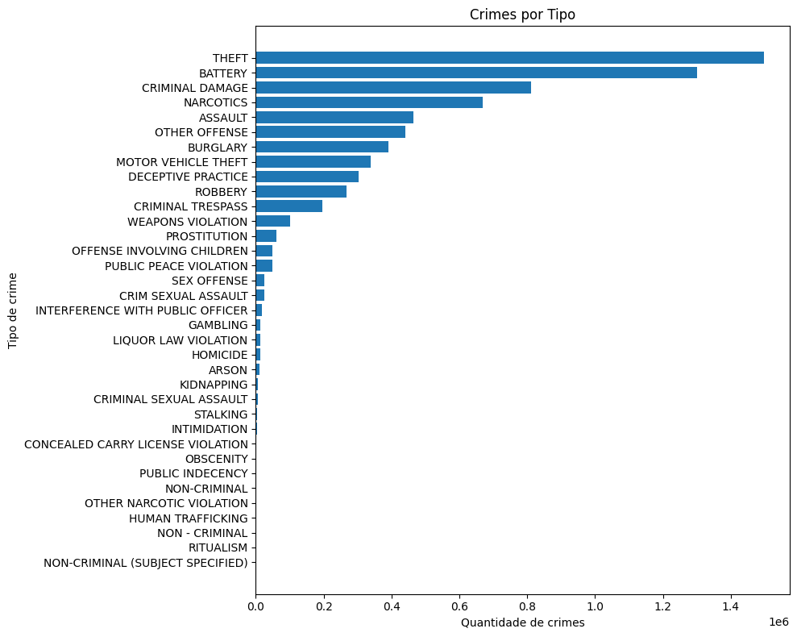

```python
import matplotlib.pyplot as plt

# Agrupamento no Spark
tipos_crimes_df = (
    crimes_df2.groupBy("primary_type")
             .count()
             .orderBy("count", ascending=False)
)

# Coletando para Pandas (seguro porque são poucas categorias)
tipos_crimes_pd = tipos_crimes_df.toPandas()

# Criar gráfico horizontal
plt.figure(figsize=(10, 8))
plt.barh(
    tipos_crimes_pd["primary_type"],
    tipos_crimes_pd["count"]
)
plt.xlabel("Quantidade de crimes")
plt.ylabel("Tipo de crime")
plt.title("Crimes por Tipo")
plt.gca().invert_yaxis()  # maior no topo
plt.tight_layout()
plt.show()
```

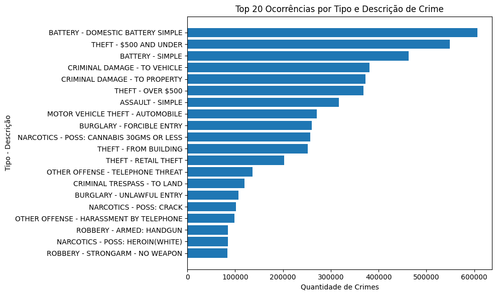

```python
desc_type_df = crimes_df2.groupBy("primary_type", "description") \
                        .count() \
                        .orderBy("count", ascending=False)
desc_type_pd = desc_type_df.toPandas()
top20 = desc_type_pd.head(20)
import matplotlib.pyplot as plt

plt.figure(figsize=(10, 6))
plt.barh(top20["primary_type"] + " - " + top20["description"], top20["count"])
plt.xlabel("Quantidade de Crimes")
plt.ylabel("Tipo - Descrição")
plt.title("Top 20 Ocorrências por Tipo e Descrição de Crime")
plt.gca().invert_yaxis()
plt.tight_layout()
plt.show()
```

```python
crimes_df2.groupBy("community_area") \
         .count() \
         .orderBy("count", ascending=False) \
         .show(15)
```

```
[Stage 46:==============================>                        (18 + 14) / 32]
```

```
+--------------+------+
|community_area| count|
+--------------+------+
|            25|443654|
|             8|249001|
|            43|234412|
|            23|221397|
|            28|213872|
|            24|207273|
|            29|206533|
|            67|203194|
|            71|201132|
|            49|188672|
|            68|185313|
|            69|176737|
|            32|175126|
|            66|173057|
|            44|156585|
+--------------+------+
only showing top 15 rows
```

```python
crimes_df2.groupBy("district") \
         .count() \
         .orderBy("count", ascending=False) \
         .show(15)
```

```
[Stage 49:>                                                       (0 + 32) / 32]
```

```
+--------+------+
|district| count|
+--------+------+
|       8|479088|
|      11|457146|
|       6|418970|
|       7|412732|
|       4|406393|
|      25|402994|
|       3|360823|
|      12|348935|
|       9|345915|
|       2|321434|
|       5|316018|
|      18|316000|
|      19|315365|
|      10|307428|
|      15|304731|
+--------+------+
only showing top 15 rows
```

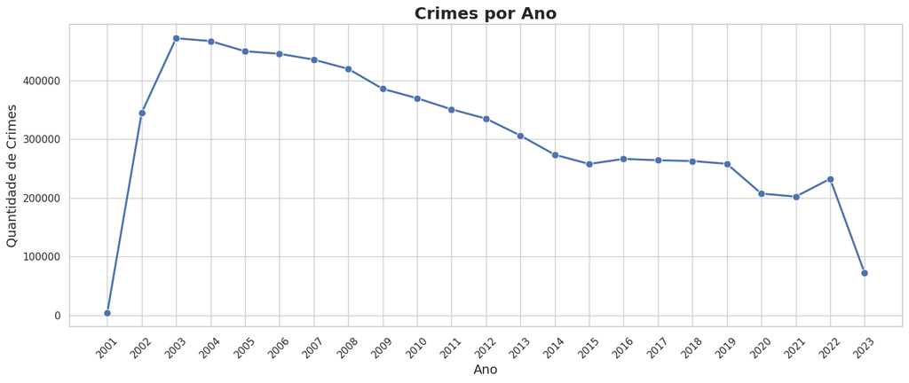

```python
crimes_por_ano = crimes_df2.groupBy("year") \
                          .count() \
                          .orderBy("year")

pdf = crimes_por_ano.toPandas()

import seaborn as sns
import matplotlib.pyplot as plt

# Tema elegante
sns.set_theme(style="whitegrid")

# Criar figura
plt.figure(figsize=(14, 6))

# Gráfico
ax = sns.lineplot(
    data=pdf,
    x="year",
    y="count",
    marker="o",
    linewidth=2.2,
    markersize=8
)

# Mostrar todos os anos no eixo X
ax.set_xticks(pdf["year"])

# Rotacionar para não sobrepor
plt.xticks(rotation=45)

# Títulos e estética
plt.title("Crimes por Ano", fontsize=18, weight='bold')
plt.xlabel("Ano", fontsize=14)
plt.ylabel("Quantidade de Crimes", fontsize=14)

# Ajusta layout pra não cortar nada
plt.tight_layout()

plt.show()
```

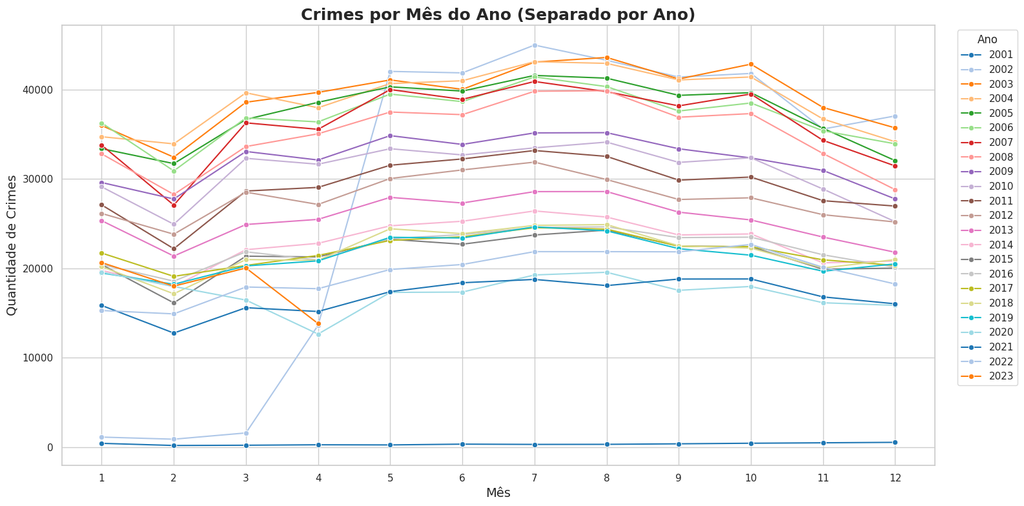

```python
from pyspark.sql.functions import hour, month, to_timestamp

crimes_df2 = crimes_df2.withColumn(
    "date_ts",
    to_timestamp("date", "MM/dd/yyyy hh:mm:ss a")
)

crimes_df2 = crimes_df2.withColumn("month", month("date_ts"))

crimes_hora_ano = crimes_df2.groupBy("year", "month") \
                           .count() \
                           .orderBy("year", "month")

pdf3 = crimes_hora_ano.toPandas()

import seaborn as sns
import matplotlib.pyplot as plt

sns.set_theme(style="whitegrid")

plt.figure(figsize=(16, 8))

ax = sns.lineplot(
    data=pdf3,
    x="month",
    y="count",
    hue="year",
    palette="tab20",
    marker="o"
)

# Mostrar todas as horas 0–23
ax.set_xticks(sorted(pdf3["month"].unique()))

plt.xticks(rotation=0)
plt.title("Crimes por Mês do Ano (Separado por Ano)", fontsize=18, weight="bold")
plt.xlabel("Mês", fontsize=14)
plt.ylabel("Quantidade de Crimes", fontsize=14)

plt.legend(title="Ano", bbox_to_anchor=(1.02, 1), loc="upper left")
plt.tight_layout()

plt.show()
```

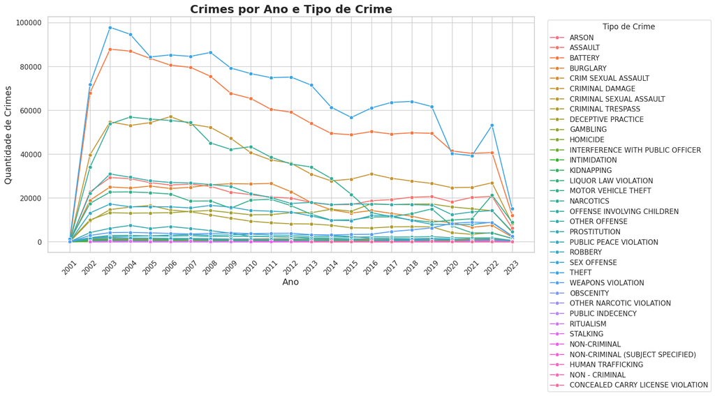

```python
crimes_tipo_ano = crimes_df2.groupBy("year", "primary_type") \
                           .count() \
                           .orderBy("year", "primary_type")

pdf2 = crimes_tipo_ano.toPandas()

import seaborn as sns
import matplotlib.pyplot as plt

sns.set_theme(style="whitegrid")

plt.figure(figsize=(16, 8))

ax = sns.lineplot(
    data=pdf2,
    x="year",
    y="count",
    hue="primary_type",      # ➜ uma linha por tipo!
    estimator=None,
    marker="o"
)

# Mostrar todos os anos no eixo X
ax.set_xticks(sorted(pdf2["year"].unique()))

plt.xticks(rotation=45)
plt.title("Crimes por Ano e Tipo de Crime", fontsize=18, weight="bold")
plt.xlabel("Ano", fontsize=14)
plt.ylabel("Quantidade de Crimes", fontsize=14)

plt.legend(title="Tipo de Crime", bbox_to_anchor=(1.02, 1), loc="upper left")
plt.tight_layout()

plt.show()
```

```python
# tirando os dados de 2001,2002 e 2023
crimes_df2 = crimes_df.filter(
    (col("year") != 2001) &
    (col("year") != 2002) &
    (col("year") != 2023)
)
# tiramos porque os dados nulos estavam concentrados em 2001 e 2002. 2023 estava com dados somente ate abril
```

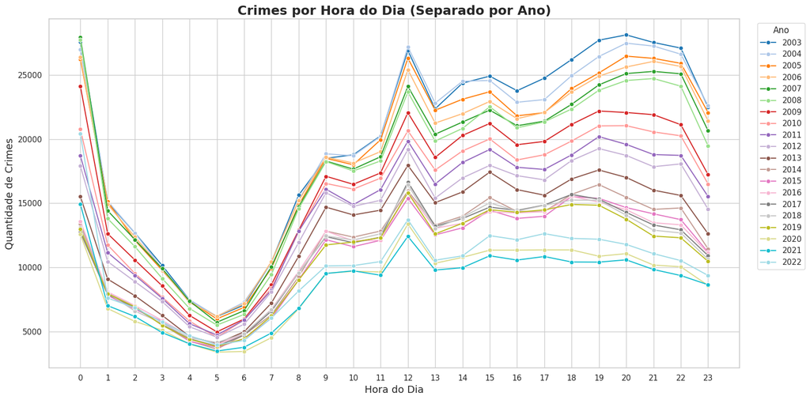

```python
from pyspark.sql.functions import hour, to_timestamp

crimes_df2 = crimes_df2.withColumn(
    "date_ts",
    to_timestamp("date", "MM/dd/yyyy hh:mm:ss a")
)

crimes_df2 = crimes_df2.withColumn("hour", hour("date_ts"))

crimes_hora_ano = crimes_df2.groupBy("year", "hour") \
                           .count() \
                           .orderBy("year", "hour")

pdf3 = crimes_hora_ano.toPandas()

import seaborn as sns
import matplotlib.pyplot as plt

sns.set_theme(style="whitegrid")

plt.figure(figsize=(16, 8))

ax = sns.lineplot(
    data=pdf3,
    x="hour",
    y="count",
    hue="year",
    palette="tab20",
    marker="o"
)

# Mostrar todas as horas 0–23
ax.set_xticks(sorted(pdf3["hour"].unique()))

plt.xticks(rotation=0)
plt.title("Crimes por Hora do Dia (Separado por Ano)", fontsize=18, weight="bold")
plt.xlabel("Hora do Dia", fontsize=14)
plt.ylabel("Quantidade de Crimes", fontsize=14)

plt.legend(title="Ano", bbox_to_anchor=(1.02, 1), loc="upper left")
plt.tight_layout()

plt.show()
```

```python
crimes_df2.limit(10).toPandas().T
```

|  | 0 | 1 | 2 | 3 | 4 | 5 | 6 | 7 | 8 | 9 |
| --- | --- | --- | --- | --- | --- | --- | --- | --- | --- | --- |
| id | 10224738 | 10224739 | 11646166 | 10224740 | 10224741 | 10224742 | 10224743 | 10224744 | 10224745 | 11645836 |
| case_number | HY411648 | HY411615 | JC213529 | HY411595 | HY411610 | HY411435 | HY411629 | HY411605 | HY411654 | JC212333 |
| date | 2015-09-05 13:30:00 | 2015-09-04 11:30:00 | 2018-09-01 00:01:00 | 2015-09-05 12:45:00 | 2015-09-05 13:00:00 | 2015-09-05 10:55:00 | 2015-09-04 18:00:00 | 2015-09-05 13:00:00 | 2015-09-05 11:30:00 | 2016-05-01 00:25:00 |
| block | 043XX S WOOD ST | 008XX N CENTRAL AVE | 082XX S INGLESIDE AVE | 035XX W BARRY AVE | 0000X N LARAMIE AVE | 082XX S LOOMIS BLVD | 021XX W CHURCHILL ST | 025XX W CERMAK RD | 031XX W WASHINGTON BLVD | 055XX S ROCKWELL ST |
| iucr | 0486 | 0870 | 0810 | 2023 | 0560 | 0610 | 0620 | 0860 | 0320 | 1153 |
| primary_type | BATTERY | THEFT | THEFT | NARCOTICS | ASSAULT | BURGLARY | BURGLARY | THEFT | ROBBERY | DECEPTIVE PRACTICE |
| description | DOMESTIC BATTERY SIMPLE | POCKET-PICKING | OVER $500 | POSS: HEROIN(BRN/TAN) | SIMPLE | FORCIBLE ENTRY | UNLAWFUL ENTRY | RETAIL THEFT | STRONGARM - NO WEAPON | FINANCIAL IDENTITY THEFT OVER $ 300 |
| location_description | RESIDENCE | CTA BUS | RESIDENCE | SIDEWALK | APARTMENT | RESIDENCE | RESIDENCE-GARAGE | GROCERY FOOD STORE | STREET | None |
| arrest | False | False | False | True | False | False | False | True | False | False |
| domestic | True | False | True | False | True | False | False | False | True | False |
| beat | 924 | 1511 | 631 | 1412 | 1522 | 614 | 1434 | 1034 | 1222 | 824 |
| district | 9 | 15 | 6 | 14 | 15 | 6 | 14 | 10 | 12 | 8 |
| ward | 12 | 29 | 8 | 35 | 28 | 21 | 32 | 25 | 27 | 15 |
| community_area | 61 | 25 | 44 | 21 | 25 | 71 | 24 | 31 | 27 | 63 |
| fbi_code | 08B | 06 | 06 | 18 | 08A | 05 | 05 | 06 | 03 | 11 |
| x_coordinate | 1165074.0 | 1138875.0 | NaN | 1152037.0 | 1141706.0 | 1168430.0 | 1161628.0 | 1159734.0 | 1155536.0 | NaN |
| y_coordinate | 1875917.0 | 1904869.0 | NaN | 1920384.0 | 1900086.0 | 1850165.0 | 1912157.0 | 1889313.0 | 1900515.0 | NaN |
| year | 2015 | 2015 | 2018 | 2015 | 2015 | 2015 | 2015 | 2015 | 2015 | 2016 |
| updated_on | 2018-02-10 15:50:01 | 2018-02-10 15:50:01 | 2019-04-06 16:04:43 | 2018-02-10 15:50:01 | 2018-02-10 15:50:01 | 2018-02-10 15:50:01 | 2018-02-10 15:50:01 | 2015-09-17 11:37:18 | 2018-02-10 15:50:01 | 2019-04-06 16:04:43 |
| latitude | 41.815117 | 41.895081 | NaN | 41.937405 | 41.881905 | 41.744377 | 41.914635 | 41.85199 | 41.882812 | NaN |
| longitude | -87.669998 | -87.765404 | NaN | -87.716652 | -87.755119 | -87.658432 | -87.681633 | -87.689217 | -87.704323 | NaN |
| location | (41.815117282, -87.669999562) | (41.895080471, -87.765400451) | None | (41.937405765, -87.716649687) | (41.881903443, -87.755121152) | (41.744378879, -87.658430635) | (41.914635603, -87.681630909) | (41.851988885, -87.689219118) | (41.88281374, -87.704325717) | None |
| date_ts | 2015-09-05 13:30:00 | 2015-09-04 11:30:00 | 2018-09-01 00:01:00 | 2015-09-05 12:45:00 | 2015-09-05 13:00:00 | 2015-09-05 10:55:00 | 2015-09-04 18:00:00 | 2015-09-05 13:00:00 | 2015-09-05 11:30:00 | 2016-05-01 00:25:00 |
| hour | 13 | 11 | 0 | 12 | 13 | 10 | 18 | 13 | 11 | 0 |

```python
from pyspark.sql.functions import hour

crimes_df2 = crimes_df2.withColumn("hour", hour("date"))
```

```python
crimes_df2.select("date", "hour").show(20, truncate=False)
```

```
+-------------------+----+
|date               |hour|
+-------------------+----+
|2015-09-05 13:30:00|13  |
|2015-09-04 11:30:00|11  |
|2018-09-01 00:01:00|0   |
|2015-09-05 12:45:00|12  |
|2015-09-05 13:00:00|13  |
|2015-09-05 10:55:00|10  |
|2015-09-04 18:00:00|18  |
|2015-09-05 13:00:00|13  |
|2015-09-05 11:30:00|11  |
|2016-05-01 00:25:00|0   |
|2015-09-05 14:00:00|14  |
|2015-09-05 11:00:00|11  |
|2015-09-05 03:00:00|3   |
|2015-09-05 12:50:00|12  |
|2015-09-03 13:00:00|13  |
|2015-09-05 11:45:00|11  |
|2015-09-05 13:30:00|13  |
|2015-07-08 00:00:00|0   |
|2015-09-05 09:55:00|9   |
|2015-09-05 12:35:00|12  |
+-------------------+----+
only showing top 20 rows
```

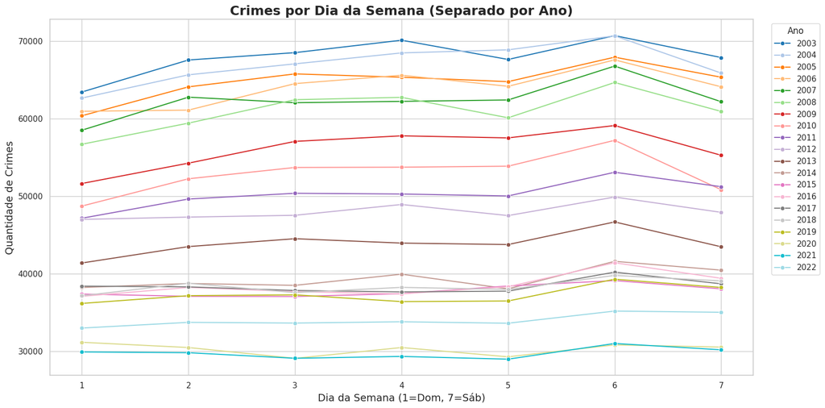

```python
from pyspark.sql.functions import dayofweek

crimes_df2 = crimes_df2.withColumn("day_of_week", dayofweek("date_ts"))

crimes_semana_ano = crimes_df2.groupBy("year", "day_of_week") \
                             .count() \
                             .orderBy("year", "day_of_week")

pdf_semana = crimes_semana_ano.toPandas()

import seaborn as sns
import matplotlib.pyplot as plt

sns.set_theme(style="whitegrid")

plt.figure(figsize=(16, 8))

ax = sns.lineplot(
    data=pdf_semana,
    x="day_of_week",
    y="count",
    hue="year",
    palette="tab20",
    marker="o"
)

# Mostrar dias 1–7
ax.set_xticks(sorted(pdf_semana["day_of_week"].unique()))

plt.xticks(rotation=0)
plt.title("Crimes por Dia da Semana (Separado por Ano)", fontsize=18, weight="bold")
plt.xlabel("Dia da Semana (1=Dom, 7=Sáb)", fontsize=14)
plt.ylabel("Quantidade de Crimes", fontsize=14)

plt.legend(title="Ano", bbox_to_anchor=(1.02, 1), loc="upper left")
plt.tight_layout()

plt.show()
```

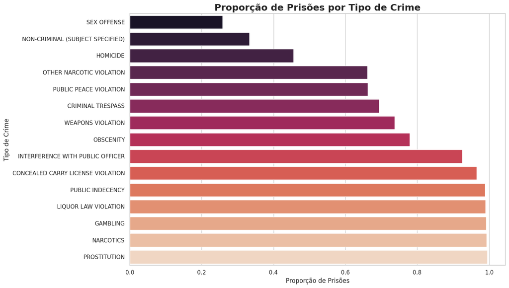

```python
from pyspark.sql.functions import col

prisao_abs = crimes_df2.filter(col("arrest") == True) \
                      .groupBy("primary_type") \
                      .count() \
                      .orderBy("count", ascending=False)

from pyspark.sql.functions import col, sum, count

prisao_prop = crimes_df2.groupBy("primary_type") \
    .agg(
        count("*").alias("total_casos"),
        sum(col("arrest").cast("int")).alias("total_prisoes")
    ) \
    .withColumn("proporcao_prisao", col("total_prisoes") / col("total_casos")) \
    .orderBy(col("proporcao_prisao").desc())

pdf_prisao = prisao_prop.toPandas()
import matplotlib.pyplot as plt
import seaborn as sns
import pandas as pd

plt.figure(figsize=(14, 8))

# ordenar por proporção
df15 = pdf_prisao.head(15).sort_values("proporcao_prisao")

sns.barplot(
    data=df15,
    x="proporcao_prisao",
    y="primary_type",
    palette="rocket",
    hue="primary_type",
    dodge=False,
    legend=False
)

plt.title("Proporção de Prisões por Tipo de Crime", fontsize=18, weight="bold")
plt.xlabel("Proporção de Prisões")
plt.ylabel("Tipo de Crime")
plt.tight_layout()
plt.show()
```

```python
from pyspark.sql.functions import create_map, lit, col

mapping = {
    1: "Rogers Park", 2: "West Ridge", 3: "Uptown", 4: "Lincoln Square",
    5: "North Center", 6: "Lake View", 7: "Lincoln Park", 8: "Near North Side",
    9: "Edison Park", 10: "Norwood Park", 11: "Jefferson Park", 12: "Forest Glen",
    13: "North Park", 14: "Albany Park", 15: "Portage Park", 16: "Irving Park",
    17: "Dunning", 18: "Montclair", 19: "Belmont Cragin", 20: "Hermosa",
    21: "Avondale", 22: "Logan Square", 23: "Humboldt Park", 24: "West Town",
    25: "Austin", 26: "West Garfield Park", 27: "East Garfield Park",
    28: "Near West Side", 29: "North Lawndale", 30: "South Lawndale",
    31: "Lower West Side", 32: "Loop", 33: "Near South Side", 34: "Armour Square",
    35: "Douglas", 36: "Oakland", 37: "Fuller Park", 38: "Grand Boulevard",
    39: "Kenwood", 40: "Washington Park", 41: "Hyde Park", 42: "Woodlawn",
    43: "South Shore", 44: "Chatham", 45: "Avalon Park", 46: "South Chicago",
    47: "Burnside", 48: "Calumet Heights", 49: "Roseland", 50: "Pullman",
    51: "South Deering", 52: "East Side", 53: "West Pullman", 54: "Riverdale",
    55: "Hegewisch", 56: "Garfield Ridge", 57: "Archer Heights",
    58: "Brighton Park", 59: "McKinley Park", 60: "Bridgeport", 61: "New City",
    62: "West Elsdon", 63: "Gage Park", 64: "Clearing", 65: "West Lawn",
    66: "Chicago Lawn", 67: "West Englewood", 68: "Englewood",
    69: "Greater Grand Crossing", 70: "Ashburn", 71: "Auburn Gresham",
    72: "Beverly", 73: "Washington Heights", 74: "Mount Greenwood",
    75: "Morgan Park", 76: "O'Hare", 77: "Edgewater"
}

# converter dict → lista alternada para create_map
mapping_expr = create_map([lit(x) for pair in mapping.items() for x in pair])

crimes_df2 = crimes_df.withColumn("community_area_name", mapping_expr[col("community_area")])
```

```python
areas_df = spark.read.csv("Boundaries_-_Community_Areas_20251201.csv", header=True, inferSchema=True)
print("Colunas do CSV:")
print(areas_df.columns)


areas_df.toPandas()
```

```
Colunas do CSV:
['the_geom', 'AREA_NUMBE', 'COMMUNITY', 'AREA_NUM_1', 'SHAPE_AREA', 'SHAPE_LEN']
```

|  | the_geom | AREA_NUMBE | COMMUNITY | AREA_NUM_1 | SHAPE_AREA | SHAPE_LEN |
| --- | --- | --- | --- | --- | --- | --- |
| 0 | MULTIPOLYGON (((-87.65455590025104 41.99816614... | 1 | ROGERS PARK | 1 | 51,259,902.4506 | 34,052.3975757 |
| 1 | MULTIPOLYGON (((-87.6846530946559 42.019484772... | 2 | WEST RIDGE | 2 | 98,429,094.8621 | 43,020.6894583 |
| 2 | MULTIPOLYGON (((-87.64102430213292 41.95480280... | 3 | UPTOWN | 3 | 65,095,642.7289 | 46,972.7945549 |
| 3 | MULTIPOLYGON (((-87.6744075678037 41.976103404... | 4 | LINCOLN SQUARE | 4 | 71,352,328.2399 | 36,624.6030848 |
| 4 | MULTIPOLYGON (((-87.67336415409336 41.93234274... | 5 | NORTH CENTER | 5 | 57,054,167.85 | 31,391.6697542 |
| ... | ... | ... | ... | ... | ... | ... |
| 72 | MULTIPOLYGON (((-87.63373383514987 41.72885272... | 73 | WASHINGTON HEIGHTS | 73 | 79,635,752.8769 | 42,222.598163 |
| 73 | MULTIPOLYGON (((-87.69645961375822 41.70714491... | 74 | MOUNT GREENWOOD | 74 | 75,584,290.0209 | 48,665.1305392 |
| 74 | MULTIPOLYGON (((-87.64215204651398 41.68508211... | 75 | MORGAN PARK | 75 | 91,877,340.6988 | 46,396.419362 |
| 75 | MULTIPOLYGON (((-87.83658087874365 41.98639611... | 76 | OHARE | 76 | 371,835,607.687 | 173,625.98466 |
| 76 | MULTIPOLYGON (((-87.65455590025104 41.99816614... | 77 | EDGEWATER | 77 | 48,449,990.8397 | 31,004.8309456 |

77 rows × 6 columns

```python
areas_clean = areas_df.select(
    col("AREA_NUM_1").cast("int").alias("community_area"),
    col("COMMUNITY").alias("community_area_name"),
    col("the_geom"),
    col("SHAPE_AREA").alias("shape_area"),
    col("SHAPE_LEN").alias("shape_len"))
```

```python
c = crimes_df2.alias("c")
a = areas_clean.alias("a")

crimes_joined = c.join(a, on="community_area", how="left")

taxa_prisao_area = crimes_joined.groupBy(col("c.community_area"), col("a.community_area_name"),col("the_geom"),) \
    .agg(
        count("*").alias("total_casos"),
        sum(col("c.arrest").cast("int")).alias("total_prisoes")
    ) \
    .withColumn("taxa_prisao", col("total_prisoes") / col("total_casos")) \
    .orderBy(col("taxa_prisao").desc())

taxa_prisao_area.toPandas()
```

|  | community_area | community_area_name | the_geom | total_casos | total_prisoes | taxa_prisao |
| --- | --- | --- | --- | --- | --- | --- |
| 0 | 26.0 | WEST GARFIELD PARK | MULTIPOLYGON (((-87.72023936013656 41.86986908... | 135522 | 58957 | 0.435036 |
| 1 | 27.0 | EAST GARFIELD PARK | MULTIPOLYGON (((-87.69157000948773 41.88819563... | 134276 | 51471 | 0.383322 |
| 2 | 25.0 | AUSTIN | MULTIPOLYGON (((-87.78941511405804 41.91751009... | 448276 | 168183 | 0.375177 |
| 3 | 23.0 | HUMBOLDT PARK | MULTIPOLYGON (((-87.69157000948773 41.88819563... | 223982 | 84005 | 0.375052 |
| 4 | 29.0 | NORTH LAWNDALE | MULTIPOLYGON (((-87.72023936013656 41.86986908... | 209901 | 77906 | 0.371156 |
| ... | ... | ... | ... | ... | ... | ... |
| 74 | 7.0 | LINCOLN PARK | MULTIPOLYGON (((-87.63181810269614 41.93258180... | 111392 | 14793 | 0.132801 |
| 75 | 72.0 | BEVERLY | MULTIPOLYGON (((-87.67308255594219 41.73565672... | 26039 | 3349 | 0.128615 |
| 76 | 9.0 | EDISON PARK | MULTIPOLYGON (((-87.80675853375328 42.00083736... | 7128 | 806 | 0.113075 |
| 77 | 0.0 | None | None | 76 | 8 | 0.105263 |
| 78 | 12.0 | FOREST GLEN | MULTIPOLYGON (((-87.76918527760162 42.00488913... | 13342 | 1392 | 0.104332 |

79 rows × 6 columns

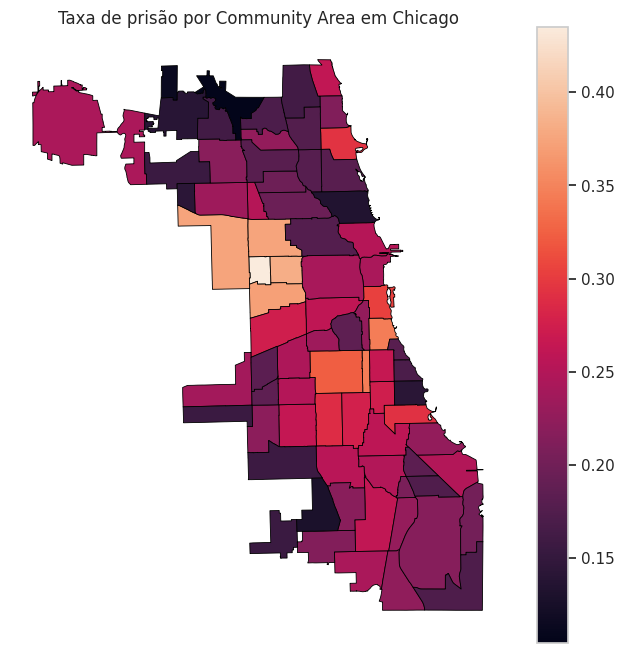

```python
from shapely import wkt
import geopandas as gpd
import matplotlib.pyplot as plt

taxa_prisao_pd = taxa_prisao_area.toPandas()

taxa_prisao_pd = taxa_prisao_pd.dropna(subset=["the_geom"])

taxa_prisao_pd["geometry"] = taxa_prisao_pd["the_geom"].apply(wkt.loads)

gdf = gpd.GeoDataFrame(
    taxa_prisao_pd,
    geometry="geometry",
    crs="EPSG:4326"
)

gdf = gdf.to_crs(epsg=3857)

fig, ax = plt.subplots(figsize=(8, 8))

gdf.plot(
    column="taxa_prisao",
    ax=ax,
    edgecolor="black",
    linewidth=0.6,
    legend=True
)

ax.set_title("Taxa de prisão por Community Area em Chicago")
ax.set_axis_off()

plt.savefig("chicago_taxa_prisao_map.png", dpi=150, bbox_inches="tight")

plt.show()
```

```python
from pyspark.sql import functions as F

crimes_prisao = crimes_df2.groupBy("arrest") \
    .count() \
    .withColumn("percent", F.col("count") / crimes_df.count() * 100) \
    .withColumn("percent", F.concat(F.format_number("percent", 2), F.lit("%")))

crimes_prisao.show()

# a variável alvo está desbalanceada
```

```
[Stage 146:=====>                                                 (3 + 29) / 32]
```

```
+------+-------+-------+
|arrest|  count|percent|
+------+-------+-------+
|  true|2034764| 26.14%|
| false|5749900| 73.86%|
+------+-------+-------+
```

```python
crimes_df2 = crimes_df2.withColumn("hour", hour(col("date")))
```

```python
from pyspark.sql.functions import col, when
from pyspark.ml.feature import StringIndexer, OneHotEncoder, VectorAssembler
from pyspark.ml.classification import LogisticRegression
from pyspark.ml import Pipeline
from pyspark.ml.evaluation import BinaryClassificationEvaluator, MulticlassClassificationEvaluator
```

```python
df_model = crimes_df2.select(
    col("arrest").cast("int").alias("label"),
    "arrest",
    col("domestic").cast("string").alias("domestic"),
    "primary_type",
    "location_description",
    col("hour").cast("int").alias("hour"),
    col("year").cast("int").alias("year"),
    col("community_area").cast("int").alias("community_area"),
    col("latitude").cast("double").alias("latitude"),
    col("longitude").cast("double").alias("longitude"),
    col("beat").cast("int").alias("beat"),
    col("district").cast("int").alias("district"),
    col("ward").cast("int").alias("ward")
)
```

```python
# 0) criar coluna 'hour' a partir da coluna de data
from pyspark.sql.functions import hour, col, when

crimes_df2 = crimes_df2.withColumn("hour", hour(col("date")))

# ==========================================
# 1. SELECIONAR COLUNAS E AJUSTAR TIPOS
# ==========================================

df_model = crimes_df2.select(
    # alvo: arrest -> vira label numérico 0/1
    col("arrest").cast("int").alias("label"),
    "arrest",

    # domestic como string para o StringIndexer
    col("domestic").cast("string").alias("domestic"),

    # categóricas
    "primary_type",
    "location_description",

    # numéricas (tipos garantidos)
    col("hour").cast("int").alias("hour"),
    col("year").cast("int").alias("year"),
    col("community_area").cast("int").alias("community_area"),
    col("latitude").cast("double").alias("latitude"),
    col("longitude").cast("double").alias("longitude"),
    col("beat").cast("int").alias("beat"),
    col("district").cast("int").alias("district"),
    col("ward").cast("int").alias("ward")
)

df_model = df_model.dropna(subset=[
    "label", "domestic", "primary_type", "location_description",
    "hour", "year", "community_area", "latitude", "longitude",
    "beat", "district", "ward"
])

print("Linhas no df_model (após dropna):", df_model.count())
df_model.printSchema()
```

```
[Stage 155:=====================================================> (31 + 1) / 32]
```

```
Linhas no df_model (após dropna): 7084438
root
 |-- label: integer (nullable = true)
 |-- arrest: boolean (nullable = true)
 |-- domestic: string (nullable = true)
 |-- primary_type: string (nullable = true)
 |-- location_description: string (nullable = true)
 |-- hour: integer (nullable = true)
 |-- year: integer (nullable = true)
 |-- community_area: integer (nullable = true)
 |-- latitude: double (nullable = true)
 |-- longitude: double (nullable = true)
 |-- beat: integer (nullable = true)
 |-- district: integer (nullable = true)
 |-- ward: integer (nullable = true)
```

```python
from pyspark.sql.functions import col

# ==========================================
# 2. CRIAR AMOSTRA MENOR (df_small)
# ==========================================

# pega ~5% da base para não estourar memória na modelagem
df_small = df_model.sample(withReplacement=False, fraction=0.05, seed=42)

print("Linhas no df_model completo :", df_model.count())
print("Linhas na amostra (df_small):", df_small.count())

# ver o desbalanceamento da variável alvo na amostra
df_small.groupBy("label").count().show()
```

```
Linhas no df_model completo : 7084438
```

```
Linhas na amostra (df_small): 353791
```

```
[Stage 164:============================================>          (26 + 6) / 32]
```

```
+-----+------+
|label| count|
+-----+------+
|    1| 91896|
|    0|261895|
+-----+------+
```

```python
from pyspark.sql.functions import when

# ==========================================
# 3. BALANCEAR A CLASSE COM WEIGHT + SPLIT
# ==========================================

# contar classe majoritária e minoritária na amostra
major = df_small.filter(col("label") == 0).count()
minor = df_small.filter(col("label") == 1).count()

print("Classe 0 (sem prisão):", major)
print("Classe 1 (com prisão):", minor)

ratio = major / minor
print("Peso aplicado à classe 1 (prisão):", ratio)

# criar coluna de peso
df_small = df_small.withColumn(
    "weight",
    when(col("label") == 1, ratio).otherwise(1.0)
)

# split treino / teste
train, test = df_small.randomSplit([0.8, 0.2], seed=42)

print("Linhas treino:", train.count())
print("Linhas teste :", test.count())
```

```
Classe 0 (sem prisão): 261895
Classe 1 (com prisão): 91896
Peso aplicado à classe 1 (prisão): 2.8499064159484635
```

```
Linhas treino: 282923
```

```
[Stage 176:=====================================================> (31 + 1) / 32]
```

```
Linhas teste : 70868
```

```python
from pyspark.ml.feature import StringIndexer, OneHotEncoder, VectorAssembler
from pyspark.ml.classification import LogisticRegression
from pyspark.ml import Pipeline

# ==========================================
# 4. PRÉ-PROCESSAMENTO + MODELO (PIPELINE)
# ==========================================

# colunas categóricas que vamos codificar
categorical_cols = [
    "primary_type",
    "location_description",
    "domestic",
    "community_area"
]

# StringIndexer: texto -> índice numérico
indexers = [
    StringIndexer(
        inputCol=c,
        outputCol=f"{c}_idx",
        handleInvalid="keep"
    )
    for c in categorical_cols
]

# OneHotEncoder: índice -> vetor binário
encoders = [
    OneHotEncoder(
        inputCols=[f"{c}_idx"],
        outputCols=[f"{c}_ohe"]
    )
    for c in categorical_cols
]

# colunas numéricas + OHE que vão virar o vetor de features
feature_cols = [
    "primary_type_ohe",
    "location_description_ohe",
    "domestic_ohe",
    "community_area_ohe",
    "hour",
    "year",
    "latitude",
    "longitude",
    "beat",
    "district",
    "ward"
]

assembler = VectorAssembler(
    inputCols=feature_cols,
    outputCol="features"
)
```

[output not shown]

[output not shown]

```python
# modelo de regressão logística usando o peso
lr = LogisticRegression(
    labelCol="label",
    featuresCol="features",
    weightCol="weight",
    maxIter=20
)

# pipeline completa: indexers -> encoders -> assembler -> modelo
pipeline_lr = Pipeline(stages=indexers + encoders + [assembler, lr])

# treinar o modelo
lr_model = pipeline_lr.fit(train)

# gerar previsões no conjunto de teste
pred_lr = lr_model.transform(test)

pred_lr.select("label", "probability", "prediction").show(10, truncate=False)
```

```python
from pyspark.ml.evaluation import BinaryClassificationEvaluator, MulticlassClassificationEvaluator
from pyspark.sql.functions import countDistinct

# ==========================================
# 5. AVALIAÇÃO DO MODELO (AUC, F1, ACCURÁCIA)
# ==========================================

# ver se temos as duas classes no teste
pred_lr.groupBy("label").count().show()

num_classes_test = pred_lr.select(countDistinct("label")).collect()[0][0]
print("Número de classes no conjunto de teste:", num_classes_test)

# --- AUC (curva ROC) ---
# usando a coluna 'probability'
evaluator_auc = BinaryClassificationEvaluator(
    labelCol="label",
    rawPredictionCol="probability",   # usa a probabilidade da classe 1
    metricName="areaUnderROC"
)

if num_classes_test > 1:
    auc_lr = evaluator_auc.evaluate(pred_lr)
    print("AUC (Logistic Regression):", auc_lr)
else:
    print("AUC não pôde ser calculado: só há uma classe no conjunto de teste.")

# --- F1-score ---
evaluator_f1 = MulticlassClassificationEvaluator(
    labelCol="label",
    predictionCol="prediction",
    metricName="f1"
)
f1_lr = evaluator_f1.evaluate(pred_lr)
print("F1 (Logistic Regression):", f1_lr)

# --- Acurácia ---
evaluator_acc = MulticlassClassificationEvaluator(
    labelCol="label",
    predictionCol="prediction",
    metricName="accuracy"
)
acc_lr = evaluator_acc.evaluate(pred_lr)
print("Accuracy (Logistic Regression):", acc_lr)
```

```
+-----+-----+
|label|count|
+-----+-----+
|    1|18430|
|    0|52438|
+-----+-----+
```

```
Número de classes no conjunto de teste: 2
```

```
AUC (Logistic Regression): 0.8762476988301116
```

```
F1 (Logistic Regression): 0.8358207838802699
```

```
[Stage 260:================================================>      (28 + 4) / 32]
```

```
Accuracy (Logistic Regression): 0.835906191793193
```

```python
from pyspark.sql.functions import col

# MATRIZ DE CONFUSÃO (tabela simples)
confusion = (
    pred_lr
      .groupBy("label", "prediction")
      .count()
      .orderBy("label", "prediction")
)

confusion.show()
```

```
[Stage 262:=========================================>             (24 + 8) / 32]
```

```
+-----+----------+-----+
|label|prediction|count|
+-----+----------+-----+
|    0|       0.0|46653|
|    0|       1.0| 5785|
|    1|       0.0| 5844|
|    1|       1.0|12586|
+-----+----------+-----+
```